# Data Management and the tidyverse

## `bind_rows()`

```r
x = data_frame(x=c(1,2),y=3)
y = data_frame(y=c(3,4), x=2)
bind_rows(x,y)
```

```
## # A tibble: 4 x 2
##       x     y
##   <dbl> <dbl>
## 1     1     3
## 2     2     3
## 3     2     3
## 4     2     4
```

```r
x = data_frame(x=c(1,2),y=3)
y = data_frame(y=c(3,4), x=2, z=0)
bind_rows(x,y)
```

```
## # A tibble: 4 x 3
##       x     y     z
##   <dbl> <dbl> <dbl>
## 1     1     3    NA
## 2     2     3    NA
## 3     2     3     0
## 4     2     4     0
```

## `bind_cols()`

```r
x = data_frame(x=c(1,2),y=3)
y = data_frame(z=c(3,4), a=2)
bind_cols(x,y)
```

```
## # A tibble: 2 x 4
##       x     y     z     a
##   <dbl> <dbl> <dbl> <dbl>
## 1     1     3     3     2
## 2     2     3     4     2
```

```r
x = data_frame(x=c(1,2),y=3)
y = data_frame(z=c(3,4,5), a=2)
bind_cols(x,y)
```

```
## Error in cbind_all(x): Argument 2 must be length 2, not 3
```

- `bind_cols()` pastes the columns from the second given df onto the columns of the first given dfs. Calling `bind_cols()` on dfs of different rowlengths is not possible.

## `left_join()`

```r
x = data_frame(id=1:4, inc=c(3000, 4000, 5000, 6000))
y = data_frame(id=1:4, location=c("Germany", "UK", "USA", "Egypt"))
left_join(x, y, "id")
```

```
## # A tibble: 4 x 3
##      id   inc location
##   <int> <dbl> <chr>
## 1     1  3000 Germany
## 2     2  4000 UK
## 3     3  5000 USA
## 4     4  6000 Egypt
```

- Say, you have one table with household IDs and their income and one table with household IDs and their location. Would it not be nice to have both tables in one table? This is possible using `left_join()`

## The Pipe

- A central operator within the tidyverse is the "pipe" operator `%>%`
- The pipe takes an input in front of it and pushes it in the function that follows after the pipe. It is effectively acting like a Pipe. It can also be imagined like an assembly line.
- \(f(g(x))\) is the same as

```r
x %>% g() %>% f()
```

```r
tutors <- c("Bene", "Marcel", "Martin", "Ben")
```

- Standard nested functions

```r
length(tutors)
```

```
## [1] 4
```

```r
nchar(tutors)
```

```
## [1] 4 6 6 3
```

```r
max(nchar(tutors))
```

```
## [1] 6
```

- Using the pipe

```r
tutors %>% length()
```

```
## [1] 4
```

```r
tutors %>% nchar()
```

```
## [1] 4 6 6 3
```

```r
tutors %>% nchar() %>% max()
```

```
## [1] 6
```

- Let us have a quick look at a better dataframe format. Instead of using base R's `data.frame()`, we will use dplyr's `data_frame()`.

```r
mydf <- data_frame(name=c("Hans", "Peter", "Anna", "Hanna"),
                   sex=c("m", "m", "w", "w"),
                   grade = c(2.3, 3.8, 1.2, 2.2))
```

[output not shown]

```r
# Checking dimensions
mydf %>% dim() # (rows x cols)
```

```
## [1] 4 3
```

```r
mydf %>% glimpse() # Get a glimpse of the dataframe
```

```
## Observations: 4
## Variables: 3
## $ name  <chr> "Hans", "Peter", "Anna", "Hanna"
## $ sex   <chr> "m", "m", "w", "w"
## $ grade <dbl> 2.3, 3.8, 1.2, 2.2
```

## Long vs. Wide format

- Dataframes can have two different formats, called "long" and "wide".

**Wide**

```
## # A tibble: 2 x 4
##      ID A     B     C
##   <int> <chr> <chr> <chr>
## 1     1 a     b     c
## 2     2 A     B     C
```

**Long**

```
## # A tibble: 6 x 3
##      ID key   Val
##   <int> <chr> <chr>
## 1     1 A     a
## 2     2 A     A
## 3     1 B     b
## 4     2 B     B
## 5     1 C     c
## 6     2 C     C
```

```r
x %>% gather(key="key", value="Val", -ID) # Wide to long
x %>% spread(key="key", value="Val") # Long to wide
```

## An example

```r
# Example for a wide dataframe
wide <- data_frame(year=2017:2018, johnny=c(200,500),
           marry=c(350, 550), richie=c(200, 200))
wide
```

```
## # A tibble: 2 x 4
##    year johnny marry richie
##   <int>  <dbl> <dbl>  <dbl>
## 1  2017    200   350    200
## 2  2018    500   550    200
```

`gather()` the data to the long format:

```r
(long <- wide %>% gather(key = "name", value = "sales", -year))
```

```
## # A tibble: 6 x 3
##    year name   sales
##   <int> <chr>  <dbl>
## 1  2017 johnny   200
## 2  2018 johnny   500
## 3  2017 marry    350
## 4  2018 marry    550
## 5  2017 richie   200
## 6  2018 richie   200
```

- key: The name of the (future) variable that holds the key (the values in the header)
- value: The name of the (future) variable holding the values (in the body)
- Exclude some columns that already relate to the observation, using `-varname` (here: `year`)

## Why long and wide?

- For some data operations and especially plots, the long format is required.
- the `lmer()` function from `lme4` also requires the data to be in long format, while the usual base `lm()` usually uses wide date.
- Consider the wide dataframe. How are we supposed to hand over our data to ggplot?

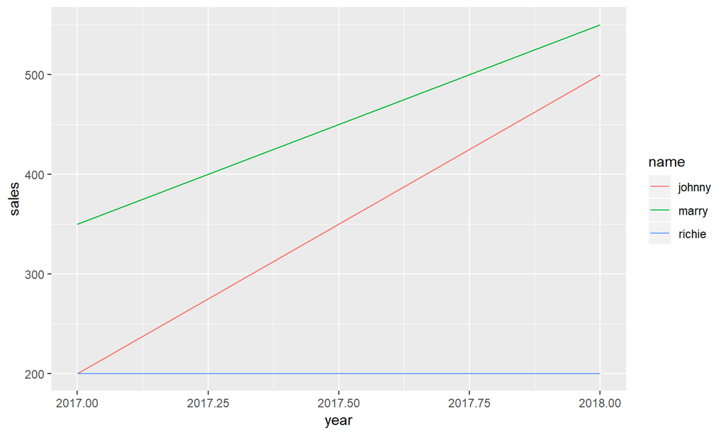

```r
# wide %>% ggplot(aes(year, c(johnny, marry, richie))) # Doesn't work. But:
long %>% ggplot(aes(year, sales, color=name)) + geom_line() # Works!
```

## Data manipulation using `%>%` and `dplyr`

- The pipe gives us the possibility to make our code more readable, but it does not really make things necessarily easier right now, at least not for data manipulation.
- This is where `dplyr`'s functions come into play:
  - `filter()` filters the rows of a table by one or more conditions
  - `select()` selects the specified columns
  - `mutate()` creates new variables or changes existing ones
  - `arrange()` sorts by a column
  - `group_by()` enables data manipulation of groups within the dataframe
- Now let's do some data manipulation!

## `filter()`

```r
(x <- data_frame(id=c(1:7),
                 group=c(rep(c("a","b"),3),"a")))
```

```
## # A tibble: 7 x 2
##      id group
##   <int> <chr>
## 1     1 a
## 2     2 b
## 3     3 a
## 4     4 b
## 5     5 a
## 6     6 b
## 7     7 a
```

```r
x %>%
  filter(group=="a")
```

```
## # A tibble: 4 x 2
##      id group
##   <int> <chr>
## 1     1 a
## 2     3 a
## 3     5 a
## 4     7 a
```

- The `filter()` command filters row-wise according to one or more criteria. Criteria can be linked by using either the "OR" operator `|` or the "AND" operator `&`.

## `select()`

```r
x %>% select(group)
```

```
## # A tibble: 7 x 1
##   group
##   <chr>
## 1 a
## 2 b
## 3 a
## 4 b
## 5 a
## 6 b
## 7 a
```

```r
x %>% select(-group)
```

```
## # A tibble: 7 x 1
##      id
##   <int>
## 1     1
## 2     2
## 3     3
## 4     4
## 5     5
## 6     6
## 7     7
```

- The `select()` command selects columns as specified. Selecting multiple columns is done by separating the column names with commas. Deselecting columns using a "-" like in the example is also possible. `startswith()` can be useful when selecting multiple variables with the same prefix.

## `mutate()`

```r
x %>% mutate(log_id=log(id))
```

```
## # A tibble: 7 x 3
##      id group log_id
##   <int> <chr>  <dbl>
## 1     1 a      0
## 2     2 b      0.693
## 3     3 a      1.10
## 4     4 b      1.39
## 5     5 a      1.61
## 6     6 b      1.79
## 7     7 a      1.95
```

```r
x %>% mutate(group=ifelse(id<=4, "a", "b"))
```

```
## # A tibble: 7 x 2
##      id group
##   <int> <chr>
## 1     1 a
## 2     2 a
## 3     3 a
## 4     4 a
## 5     5 b
## 6     6 b
## 7     7 b
```

- The `mutate()` command creates new variables or changes existing ones. Like in the example, existing variables can be part of the new variable declaration. In the example, for the new variable "log_id" each row of the id column is logarithmised. With `ifelse()`, it is possible to mutate variables on a condition.

## `arrange()`

```r
x %>% arrange(group)
```

```
## # A tibble: 7 x 2
##      id group
##   <int> <chr>
## 1     1 a
## 2     3 a
## 3     5 a
## 4     7 a
## 5     2 b
## 6     4 b
## 7     6 b
```

```r
x %>% arrange(desc(id))
```

```
## # A tibble: 7 x 2
##      id group
##   <int> <chr>
## 1     7 a
## 2     6 b
## 3     5 a
## 4     4 b
## 5     3 a
## 6     2 b
## 7     1 a
```

- The `arrange()` command sorts the dataframe by the specified column. calling `desc()` on the column will make `arrange()` sorting in descending order. Hierarchical sorting is possible by passing more than one variable into `arrange()`.

## `group_by()`

```r
x %>% group_by(group) %>%
  mutate(no_obs=n())
```

```
## # A tibble: 7 x 3
## # Groups:   group [2]
##      id group no_obs
##   <int> <chr>  <int>
## 1     1 a          4
## 2     2 b          3
## 3     3 a          4
## 4     4 b          3
## 5     5 a          4
## 6     6 b          3
## 7     7 a          4
```

```r
x %>% group_by(group) %>%
  summarise(sum_id=sum(id))
```

```
## # A tibble: 2 x 2
##   group sum_id
##   <chr>  <int>
## 1 a         16
## 2 b         12
```

- Grouping variables is useful if operations should be executed group-wise. The `n()` command counts the rows in the current group context. `summarise()` summarises information in the current group context with the given function.

## Exercise Time

- Now open and solve the tidyverse introduction exercises!

## Example using `dplyr` and pipes

```r
# install.packages("nycflights13")
library(nycflights13) # Loading the flights dataset
flights %>% glimpse(width = 80)
```

```
## Observations: 336,776
## Variables: 19
## $ year           <int> 2013, 2013, 2013, 2013, 2013, 2013, 2013, 2013, 2013...
## $ month          <int> 1, 1, 1, 1, 1, 1, 1, 1, 1, 1, 1, 1, 1, 1, 1, 1, 1, 1...
## $ day            <int> 1, 1, 1, 1, 1, 1, 1, 1, 1, 1, 1, 1, 1, 1, 1, 1, 1, 1...
## $ dep_time       <int> 517, 533, 542, 544, 554, 554, 555, 557, 557, 558, 55...
## $ sched_dep_time <int> 515, 529, 540, 545, 600, 558, 600, 600, 600, 600, 60...
## $ dep_delay      <dbl> 2, 4, 2, -1, -6, -4, -5, -3, -3, -2, -2, -2, -2, -2,...
## $ arr_time       <int> 830, 850, 923, 1004, 812, 740, 913, 709, 838, 753, 8...
## $ sched_arr_time <int> 819, 830, 850, 1022, 837, 728, 854, 723, 846, 745, 8...
## $ arr_delay      <dbl> 11, 20, 33, -18, -25, 12, 19, -14, -8, 8, -2, -3, 7,...
## $ carrier        <chr> "UA", "UA", "AA", "B6", "DL", "UA", "B6", "EV", "B6"...
## $ flight         <int> 1545, 1714, 1141, 725, 461, 1696, 507, 5708, 79, 301...
## $ tailnum        <chr> "N14228", "N24211", "N619AA", "N804JB", "N668DN", "N...
## $ origin         <chr> "EWR", "LGA", "JFK", "JFK", "LGA", "EWR", "EWR", "LG...
## $ dest           <chr> "IAH", "IAH", "MIA", "BQN", "ATL", "ORD", "FLL", "IA...
## $ air_time       <dbl> 227, 227, 160, 183, 116, 150, 158, 53, 140, 138, 149...
## $ distance       <dbl> 1400, 1416, 1089, 1576, 762, 719, 1065, 229, 944, 73...
## $ hour           <dbl> 5, 5, 5, 5, 6, 5, 6, 6, 6, 6, 6, 6, 6, 6, 6, 5, 6, 6...
## $ minute         <dbl> 15, 29, 40, 45, 0, 58, 0, 0, 0, 0, 0, 0, 0, 0, 0, 59...
## $ time_hour      <dttm> 2013-01-01 05:00:00, 2013-01-01 05:00:00, 2013-01-0...
```

The beauty of dplyr becomes apparent when performing operation like the following.

```r
flights %>%
  select(-arr_time, -dep_time,
         -sched_dep_time, -sched_arr_time) %>%  # Dropping columns
  filter(distance >= 500) %>%  # Selecting flights with at least 500 miles distance
  filter(!is.na(arr_delay)) %>%  # Selecting flights where delay information is available
  group_by(carrier) %>% # Grouping by carrier
  summarise(mean_delay = mean(arr_delay)) %>% # Calculating the mean arrival
                                              # delay for each carrier
  arrange(desc(mean_delay)) %>% # arrange by delay in descending order
  mutate(punctual = ifelse(mean_delay<5, # Create a new variable "punctual" and assign
                           "usually on time", # "on time" if mean delay is less than 5
                           "usually delayed")) %>%  # and "delayed", if it is greater
  filter(punctual == "usually on time") %>% # keep only the carriers that are on time
  arrange(mean_delay) # ...and sort them in ascending order
```

```
## # A tibble: 7 x 3
##   carrier mean_delay punctual
##   <chr>        <dbl> <chr>
## 1 AS          -9.93  usually on time
## 2 HA          -6.92  usually on time
## 3 AA           0.293 usually on time
## 4 DL           1.67  usually on time
## 5 VX           1.76  usually on time
## 6 US           2.05  usually on time
## 7 UA           3.42  usually on time
```

- To understand the whole procedure step by step, it is advisable to execute the code line by line, excluding the concluding `%>%` for each line.
- **Exercise**: Open the tidyverse assignment sheet. See if you can solve it using the `%>%` operator and the `dplyr` commands!

## Dplyr commands

```r
flights %>%
  select(-arr_time, -dep_time,
         -sched_dep_time, -sched_arr_time) %>%  # Dropping columns
  filter(distance >= 500) %>%  # Selecting flights with at least 500 miles distance
  filter(!is.na(arr_delay)) %>%  # Selecting flights where delay information is available
  group_by(carrier) %>% # Grouping by carrier
  summarise(mean_delay = mean(arr_delay)) %>% # Calculating the mean arrival
                                              # delay for each carrier
  arrange(desc(mean_delay)) %>% # arrange by delay in descending order
  mutate(punctual = ifelse(mean_delay<5, # Create a new variable "punctual" and assign
                           "usually on time", # "on time" if mean delay is less than 5
                           "usually delayed")) %>%  # and "delayed", if it is greater
  filter(punctual == "usually on time") %>% # keep only the carriers that are on time
  arrange(mean_delay) # ...and sort them in ascending order
```

[output not shown]